# 12/13 update

Linda Gai

12/13/2018

```r
library(dplyr)
library(ggplot2)
```

## Cleaning vcf

The raw vcf `/dcl01/beaty/data/gmkf/euro/vcfs/filtered/8q24.recode.vcf` was cleaned by:

1. Removing all tri-alellic SNPs
2. Individuals with Mendelian errors
3. Phased using BEAGLE 4.0 (i.e., half calls were not removed).
4. Monomorphic SNPs were removed.

TODO: filter to MAF cut-off to 0.05 or 0.01 (is MAF possibly captured in functional annotation information)?

## Filtering

The ultimate goal was to run all 3 tests on the same datasets to compare results. Since rvTDT uses allele frequencies in the population to weight SNPs in the case-parent trios, I first filtered to all SNPs that had allele frequences in Europeans available from 1000Genomes from Aug 2015 (in the Annovar Report). I then created datasets with 3 different types of filters.

### 1. Filtered by functional annotation information (848 SNPs)

I filtered to SNPs with scores (in the ANNOVAR report) of CADD > 10, GWAVA > 0.4, EIGEN >4, using recommended cut-offs from literature, or, in the case of EIGEN, a cut-off used in at least one paper. I used these scores because the other annotation scores (SIFT, PolyPhen) were completely missing from the ANNOVAR report. Unfortunately, there was high degree of missingness in each of the scores, so this approach may have excluded some posibly causal SNPs if no annotation score was available for them.

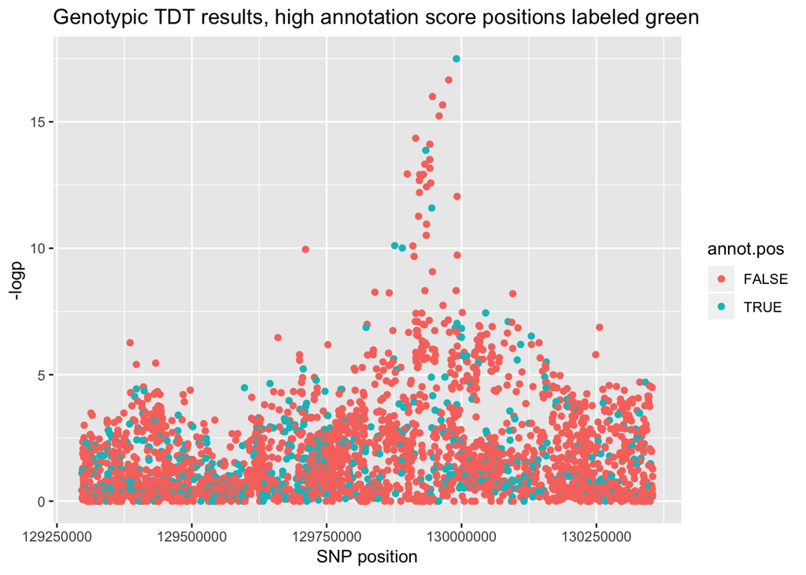

```r
ggplot(genotypic_tdt_results)+
  geom_point(aes(x=position,y=neglogp,color=annot.pos)) +
  labs(title="Genotypic TDT results, high annotation score positions labeled green",
       x="SNP position", y = "-logp")
```

### 2. Filtered to region with peak TDT signal (512 SNPs)

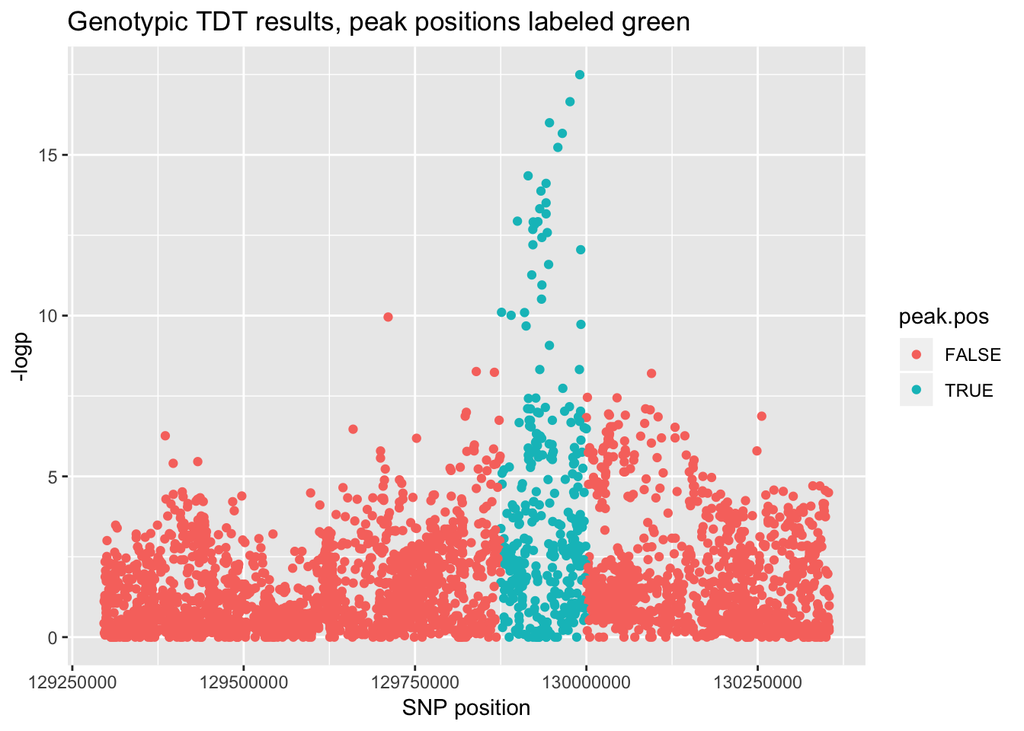

```r
ggplot(genotypic_tdt_results)+
  geom_point(aes(x=position,y=neglogp,color=peak.pos)) +
  labs(title="Genotypic TDT results, peak positions labeled green",
       x="SNP position", y = "-logp")
```

### 3. Both 1 and 2 (102 SNPs)

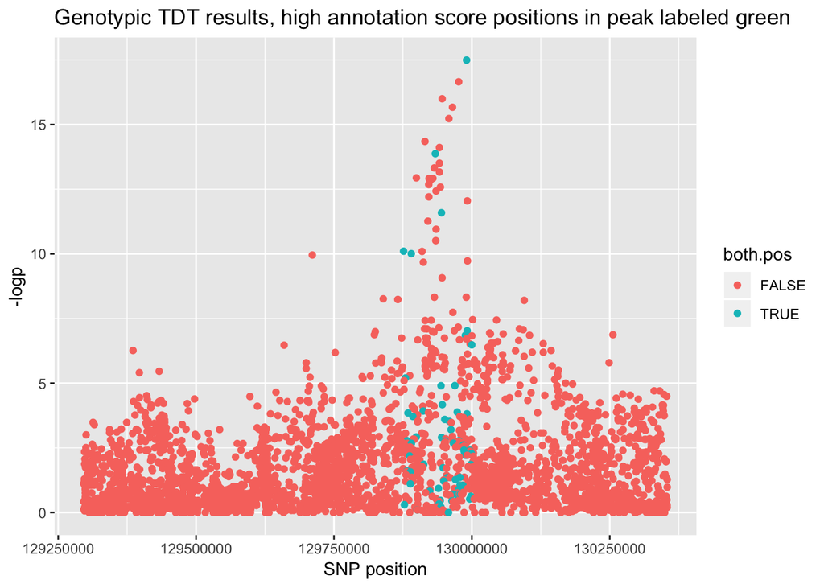

```r
ggplot(genotypic_tdt_results)+
  geom_point(aes(x=position,y=neglogp,color=both.pos)) +
  labs(title="Genotypic TDT results, high annotation score positions in peak labeled green",
       x="SNP position", y = "-logp")
```

Other types of filtering to try:

1. Filtering to high gTDT signal positions? There does not seem to much concordance between having a high annotation score and high gTDT signal, and some higher signal positions lie outside the peak.
2. Filtering to only rare variants of MAF <0.05 in 1000 genomes? in the dataset? Is there correlation between high functional annotation scores and variant rarity?
3. Filtering to smaller windows – I’ve only tried filtering to relatively large windows (76-100 SNPs) using RV-TDT.

## Results

#### rvTDT

The p-values from the gTDTs using kernels also tend to be lower than the gTDTs using linear combinations, with the kernels weighted by the population controls giving the lowest p-values of all.

KEY:

- p_lc_1: p-value from gTDT w/unweighted linear combination of SNPs
- p_lc_maf: p-value from gTDTw/linear combination of SNPs, weighted by MAF
- p_lc_pc: p-value from gTDT w/linear combination of SNPs, weighted by MAF
- p_k_1: p-value from gTDT w/unweighted kernel SNPs, weighted by population controls (i.e MAF in the population)
- p_k_maf: p-value from gTDT w/kernel of SNPs, weighted by MAF
- p_k_pc: p-value from gTDT w/kernel of SNPs, weighted by by population controls (i.e MAF in the population)

#### 1. Filtered by functional annotation information (CADD > 10, GWAVA > 0.4, EIGEN >4, using literature) using cut-offs

```r
unlist(readRDS(rvTDT.results[1]))
```

```
##      nsnptot      nfamily  nsnpcompute       p_lc_1     p_lc_maf
## 8.480000e+02 3.270000e+02 8.480000e+02 4.067433e-01 2.772739e-01
##      p_lc_pc        p_k_1      p_k_maf       p_k_pc
## 4.951113e-01 2.532555e-03 3.073901e-01 2.104510e-03
```

#### 2. Filtered to peak TDT signal

```r
unlist(readRDS(rvTDT.results[2]))
```

```
##      nsnptot      nfamily  nsnpcompute       p_lc_1     p_lc_maf
## 5.120000e+02 3.270000e+02 5.120000e+02 4.277440e-02 2.946868e-01
##      p_lc_pc        p_k_1      p_k_maf       p_k_pc
## 1.627101e-01 2.272553e-05 6.763234e-02 0.000000e+00
```

#### 3. Both 1 and 2

```r
unlist(readRDS(rvTDT.results[3]))
```

```
##      nsnptot      nfamily  nsnpcompute       p_lc_1     p_lc_maf
## 1.020000e+02 3.270000e+02 1.020000e+02 5.976463e-02 9.973608e-01
##      p_lc_pc        p_k_1      p_k_maf       p_k_pc
## 1.469100e-01 2.381726e-04 8.929723e-02 7.197620e-06
```

## Alternative Filtering approach

#### Windows of size 100, filtered to CADD>10, overlap of 0 and 10, in peak and in whole region

#### RV-TDT

Over the summer, I also tried using windows and filtering on RV-TDT. I first filtered to all positions with a CADD score >10, since that annotation score had the most non-missing entries in the region. I then used relatively large windows of 76 or 100 SNPs, with either no overlap or a 10 SNP overlap between the windows.

#### Results

##### Overall findings; highest signal is possibly outside of the peak

Adding overlaps changed the p-values somewhat. The 2 smallest p-values in the overlap data set were 0.11 and 0.2 (SNPs ~540-630, 630-720), compared to 0.25 and 0.13 in the non-overlap data set (SNPs 600-700,700-800).

##### P-values differed widely based on weighting scheme in region

The p-values differed quite a lot between the different weighting schemes.

##### Lowest p-value method used indicator of whether parent transmitted a RV, association between RV carrier status and phenotype

CMC-Analytical and CMC-Haplo gave relatively low p-values for this region (0.16-0.4). The CMC statistics are the simplest, and just use an indicator variable to indicate whether the parent has rare variants and tests for the association between phenotype and rare variant carrier status. So it seems probable/possible that there is some variant in the 600-800th SNP region that might be associated with cleft phenotype, although the test did not reach significance.

##### Highest p-value methods were weighted by the number of (or variance in the number of) variants transmitted per parent

Conversely, BRV-Haplo, VT-BRV-Haplo, and WSS-Haplo gave relatively higher p-values (~0.5-0.75). BRV counts the number of rare variants transmitted, WSS weights each variant site by the number of variants in the parental haplotypes that are not transmitted in the parental off-spring, and VT maximizes the test statistic over the allele frequencies.

##### QUESTION/TODO: Does this imply that, of the rare variants transmitted, only a small number are associated with the phenotype? Or that parents that transmitted an associated rare variant transmitted only a few rare variants?

##### One method that gave a low and high p-value maximizes test statistic over allele frequencies

The VT-CMC-Haplo gave a fairly high p-value for the 600th-700th SNPs (~0.75) but a relatively low p-value for the 700-800th SNPs (~0.3).

##### QUESTION/TODO: How to interpret the information in light of the fact that VT maximizes the test statistic over the allele frequencies? VT is implemented using CMC, so I think the low p-value probably comes from the CMC part, rather than the VT part…the CMC-Analytical p-value (0.13) is quite a lot lower than the VT-CMC (~0.3)

##### P-values within peak relatively high

TODO:

1. Plot the position of the 600-800th SNPs group on the gTDT dataset.
2. Make the below tables easier to read :)

Results are here:

# Whole 8q24 region, no overlap, 100 SNPs per window

```
## #gene    CMC-Analytical  BRV-Haplo   CMC-Haplo   VT-BRV-Haplo    VT-CMC-Haplo    WSS-Haplo    8q24   0.758080    0.950495    0.841584    0.930693    0.811881    0.940594
##
## #gene    CMC-Analytical  BRV-Haplo   CMC-Haplo   VT-BRV-Haplo    VT-CMC-Haplo    WSS-Haplo    8q24   0.993336    1.000000    1.000000    1.000000    1.000000    1.000000
##
## #gene    CMC-Analytical  BRV-Haplo   CMC-Haplo   VT-BRV-Haplo    VT-CMC-Haplo    WSS-Haplo    8q24   0.828798    0.950495    0.940594    0.742574    0.564356    0.900990
##
## #gene    CMC-Analytical  BRV-Haplo   CMC-Haplo   VT-BRV-Haplo    VT-CMC-Haplo    WSS-Haplo    8q24   0.344578    0.940594    0.792079    0.920792    0.811881    0.960396
##
## #gene    CMC-Analytical  BRV-Haplo   CMC-Haplo   VT-BRV-Haplo    VT-CMC-Haplo    WSS-Haplo    8q24   0.980526    1.000000    1.000000    0.980198    0.980198    1.000000
##
## #gene    CMC-Analytical  BRV-Haplo   CMC-Haplo   VT-BRV-Haplo    VT-CMC-Haplo    WSS-Haplo    8q24   0.251167    0.653465    0.415842    0.653465    0.752475    0.623762
##
## #gene    CMC-Analytical  BRV-Haplo   CMC-Haplo   VT-BRV-Haplo    VT-CMC-Haplo    WSS-Haplo    8q24   0.134728    0.594059    0.168317    0.613861    0.297030    0.623762
##
## #gene    CMC-Analytical  BRV-Haplo   CMC-Haplo   VT-BRV-Haplo    VT-CMC-Haplo    WSS-Haplo    8q24   0.900986    0.851485    0.940594    0.584158    0.683168    0.673267
##
## #gene    CMC-Analytical  BRV-Haplo   CMC-Haplo   VT-BRV-Haplo    VT-CMC-Haplo    WSS-Haplo    8q24   0.618488    0.762376    0.574257    0.722772    0.693069    0.732673
```

# Whole 8q24 region, 10 overlap, 100 SNPs per window

```
## #gene    CMC-Analytical  BRV-Haplo   CMC-Haplo   VT-BRV-Haplo    VT-CMC-Haplo    WSS-Haplo    8q24   0.758080    0.930693    0.821782    0.891089    0.801980    0.940594
##
## #gene    CMC-Analytical  BRV-Haplo   CMC-Haplo   VT-BRV-Haplo    VT-CMC-Haplo    WSS-Haplo    8q24   0.981556    0.980198    0.980198    0.970297    0.970297    0.980198
##
## #gene    CMC-Analytical  BRV-Haplo   CMC-Haplo   VT-BRV-Haplo    VT-CMC-Haplo    WSS-Haplo    8q24   0.901647    0.960396    0.960396    0.940594    0.920792    0.950495
##
## #gene    CMC-Analytical  BRV-Haplo   CMC-Haplo   VT-BRV-Haplo    VT-CMC-Haplo    WSS-Haplo    8q24   0.769659    0.960396    0.930693    0.940594    0.891089    0.930693
##
## #gene    CMC-Analytical  BRV-Haplo   CMC-Haplo   VT-BRV-Haplo    VT-CMC-Haplo    WSS-Haplo    8q24   0.979430    0.990099    0.990099    0.990099    0.990099    0.990099
##
## #gene    CMC-Analytical  BRV-Haplo   CMC-Haplo   VT-BRV-Haplo    VT-CMC-Haplo    WSS-Haplo    8q24   0.610283    0.643564    0.782178    0.455446    0.633663    0.465347
##
## #gene    CMC-Analytical  BRV-Haplo   CMC-Haplo   VT-BRV-Haplo    VT-CMC-Haplo    WSS-Haplo    8q24   0.112626    0.623762    0.346535    0.623762    0.594059    0.564356
##
## #gene    CMC-Analytical  BRV-Haplo   CMC-Haplo   VT-BRV-Haplo    VT-CMC-Haplo    WSS-Haplo    8q24   0.199538    0.485149    0.168317    0.495050    0.396040    0.475248
##
## #gene    CMC-Analytical  BRV-Haplo   CMC-Haplo   VT-BRV-Haplo    VT-CMC-Haplo    WSS-Haplo    8q24   0.764851    0.683168    0.752475    0.485149    0.643564    0.504950
```

# TDT peak, no overlap, 100 SNPs

```
## #gene    CMC-Analytical  BRV-Haplo   CMC-Haplo   VT-BRV-Haplo    VT-CMC-Haplo    WSS-Haplo    8q24   0.500000    0.564356    0.603960    0.702970    0.742574    0.613861
##
## #gene    CMC-Analytical  BRV-Haplo   CMC-Haplo   VT-BRV-Haplo    VT-CMC-Haplo    WSS-Haplo    8q24   0.892577    0.930693    0.900990    0.940594    0.930693    0.940594
```

# TDT peak, no overlap, 76 SNPs

```
## #gene    CMC-Analytical  BRV-Haplo   CMC-Haplo   VT-BRV-Haplo    VT-CMC-Haplo    WSS-Haplo    8q24   0.434709    0.485149    0.514851    0.564356    0.564356    0.544554
##
## #gene    CMC-Analytical  BRV-Haplo   CMC-Haplo   VT-BRV-Haplo    VT-CMC-Haplo    WSS-Haplo    8q24   0.891876    0.910891    0.861386    0.950495    0.980198    0.950495
```